Análisis de maduración en el Arándano  
**Raúl Cabrera Soles**  
2024-06-01

## Presentación

Este informe se basa en un análisis exhaustivo de una base de datos proporcionada, con la libertad de publicación pero sin incluir el código específico utilizado. Su propósito es ofrecer una guía integral para la exploración y el análisis de la información, desde la exploración de datos (EDA) hasta el modelado estadístico, proporcionando un enfoque claro para mejorar las prácticas actuales en el análisis de datos.

En el contexto actual, la inteligencia artificial representa una oportunidad invaluable para optimizar procesos y mejorar la toma de decisiones basada en datos. Este informe ilustra cómo estas herramientas avanzadas pueden ser aplicadas para obtener resultados significativos y alcanzables. La intención es proporcionar una perspectiva útil y aplicable tanto para profesionales del sector como para aquellos ajenos a él, destacando la viabilidad de la innovación y el perfeccionamiento de los métodos existentes.

Este informe pretende ser un punto de partida para la evolución continua en el análisis de datos, promoviendo un diálogo constructivo sobre cómo se pueden aplicar nuevas metodologías para mejorar nuestras prácticas. La información aquí presentada está destinada a estimular la reflexión y a fomentar el progreso en el campo, ofreciendo un marco para la adaptación y la mejora continua.

## Objetivo

El objetivo principal de este informe es analizar la cantidad de días que transcurre desde el estado de “flor cerrada” hasta el estado de “azul” en el proceso de maduración del arándano.

Para lograr este objetivo, se abordarán las siguientes áreas clave:

- **Exploración de Datos:** Realizar un análisis detallado de la información disponible, evaluando cómo varía el tiempo de transición entre diferentes estadios y meses de marcación.
- **Pruebas Estadísticas:** Evaluar si la variable “Mes de Marcación” tiene un efecto significativo sobre el tiempo de transición, utilizando pruebas estadísticas apropiadas para determinar la significancia de estos efectos.
- **Modelado Estadístico:** Aplicar modelos estadísticos adecuados para analizar la cantidad de días desde “flor cerrada” a “azul”, considerando la posible falta de normalidad en los datos y realizando un análisis de supervivencia si es necesario.

## Exploración de Datos

### Librerías

```r
#Cargamos las librerías necesarias para el análisis

library(readxl)         #Lectura de Excel
library(dplyr)          #Transformacion de datos
library(survival)       #Análisis de supervivencia
library(ggplot2)        #Gráficos y EDA
library(funModeling)    #EDA y Análisis de Datos
library(FSA)            #Pruebas estadísticas no paramétricas
library(survminer)      #Análisis de supervivencia
```

### Lectura de la data

```
## tibble [26,743 × 8] (S3: tbl_df/tbl/data.frame)
##  $ Fecha        : POSIXct[1:26743], format: "2023-12-01" "2023-12-02" ...
##  $ Semana       : num [1:26743] 48 48 49 49 49 49 49 50 50 50 ...
##  $ Parcela      : chr [1:26743] "SEMA" "SEMA" "SEMA" "SEMA" ...
##  $ Lote         : chr [1:26743] "S16" "S16" "S16" "S16" ...
##  $ Variedad     : chr [1:26743] "Ventura" "Ventura" "Ventura" "Ventura" ...
##  $ Mes_Marcacion: chr [1:26743] "Diciembre" "Diciembre" "Diciembre" "Diciembre" ...
##  $ ID_Baya      : num [1:26743] 1 1 1 1 1 1 1 1 1 1 ...
##  $ Estadio      : chr [1:26743] "Flor Cerrada" "Flor Cerrada" "Flor Cerrada" "Flor Cerrada" ...
```

```
## # A tibble: 5 × 8
##   Fecha               Semana Parcela Lote  Variedad Mes_Marcacion ID_Baya
##   <dttm>               <dbl> <chr>   <chr> <chr>    <chr>           <dbl>
## 1 2023-12-01 00:00:00     48 SEMA    S16   Ventura  Diciembre           1
## 2 2023-12-02 00:00:00     48 SEMA    S16   Ventura  Diciembre           1
## 3 2023-12-04 00:00:00     49 SEMA    S16   Ventura  Diciembre           1
## 4 2023-12-05 00:00:00     49 SEMA    S16   Ventura  Diciembre           1
## 5 2023-12-06 00:00:00     49 SEMA    S16   Ventura  Diciembre           1
## # ℹ 1 more variable: Estadio <chr>
```

La base de datos contiene 26,743 filas y 8 columnas. A continuación, observamos que:

- Es necesario convertir la variable de fecha a un formato de tipo Date para un análisis más preciso.
- Es importante analizar las variables categóricas para entender su estructura y posibles valores únicos.

### Análisis de la información

```
##        variable q_zeros p_zeros q_na p_na q_inf p_inf      type unique
## 1         Fecha       0       0    0    0     0     0      Date    156
## 2        Semana       0       0    0    0     0     0   numeric     30
## 3       Parcela       0       0    0    0     0     0 character      1
## 4          Lote       0       0    0    0     0     0 character      2
## 5      Variedad       0       0    0    0     0     0 character      1
## 6 Mes_Marcacion       0       0    0    0     0     0 character      5
## 7       ID_Baya       0       0    0    0     0     0   numeric    120
## 8       Estadio       0       0    0    0     0     0 character     10
```

Análisis:

- Observamos que todas las 8 variables están completas, sin valores nulos (NA) ni ceros en las variables categóricas (q_zeros y q_na). Es algo bueno para continuar con un analisis mas profundo.
- El conjunto de datos contiene 2 variables numéricas, 5 categóricas y 1 de tipo fecha (Date).
- Aunque la variable ID_Baya nos indica que es numérica, su función es identificativa (es decir, tiene etiquetas repetidas para cada mes). Por lo tanto, debe tratarse como una variable categórica. Será necesario reestructurarla para un análisis más preciso.

### Análisis de la variable “Fecha”

```
## # A tibble: 3 × 8
##   Fecha      Semana Parcela Lote  Variedad Mes_Marcacion ID_Baya Estadio
##   <date>      <dbl> <chr>   <chr> <chr>    <chr>           <dbl> <chr>
## 1 2023-12-01     48 SEMA    S16   Ventura  Diciembre           1 Flor Cerrada
## 2 2023-12-02     48 SEMA    S16   Ventura  Diciembre           1 Flor Cerrada
## 3 2023-12-04     49 SEMA    S16   Ventura  Diciembre           1 Flor Cerrada
```

- Primero, es crucial asegurarse de que la variable Fecha esté correctamente convertida al tipo Date.

```
##         Min.      1st Qu.       Median         Mean      3rd Qu.         Max.
## "2023-09-01" "2023-10-21" "2023-12-04" "2023-12-01" "2024-01-11" "2024-03-20"
```

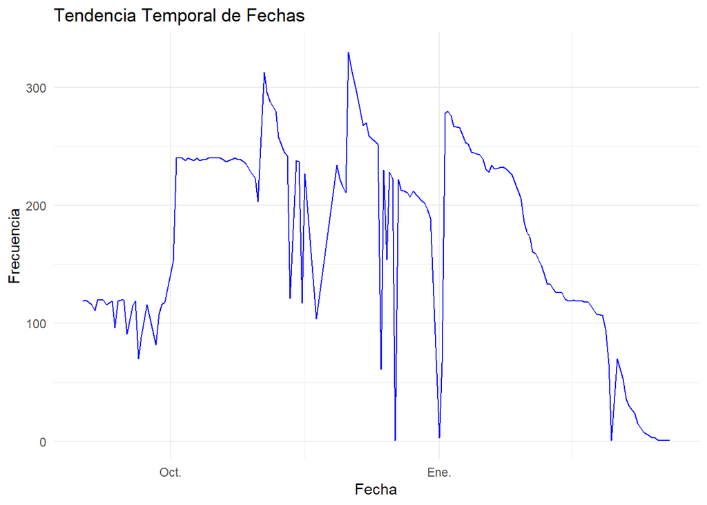

- La tabla nos indica que los ensayos inician el 01 de septiembre de 2023 y finalizan el 20 de marzo de 2024.
- En el gráfico no se observa un patrón claro. Este comportamiento sugiere que podría haber factores estacionales o específicos del periodo que influyen en la frecuencia de los datos.
- Para comprender mejor estos patrones, se debe investigar qué variables (como Parcela, Lote, Variedad, Mes_Marcacion y Estadio) podrían estar afectando la frecuencia de los datos en estos periodos específicos.

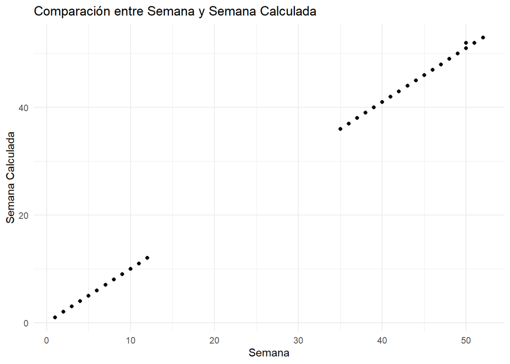

```
## # A tibble: 5 × 2
##   Mes_Marcacion FechaMinima
##   <chr>         <date>
## 1 Setiembre     2023-09-01
## 2 Octubre       2023-10-02
## 3 Noviembre     2023-11-02
## 4 Diciembre     2023-12-01
## 5 Enero         2024-01-03
```

- La agrupación de datos por Mes_Marcacion y el cálculo de la fecha mínima nos indican que los ensayos comienzan en diferentes fechas dependiendo del mes de marcación.
- Esto nos ayuda a entender la secuencia temporal de los ensayos y cómo Mes_Marcacion influye en el cronograma.

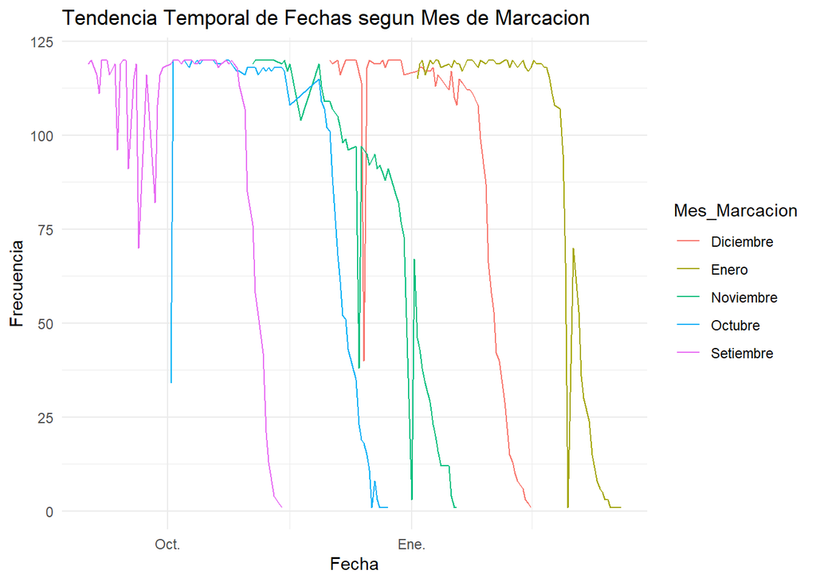

### Análisis de las variables “Parcela, Lote y Variedad”

```
##   Parcela frequency percentage cumulative_perc
## 1    SEMA     26743        100             100
##
##   Lote frequency percentage cumulative_perc
## 1  S11     13443      50.27           50.27
## 2  S16     13300      49.73          100.00
##
##   Variedad frequency percentage cumulative_perc
## 1  Ventura     26743        100             100
```

```
## [1] "Variables processed: Parcela, Lote, Variedad"
```

- La única parcela identificada en los datos es “SEMA”.
- Los lotes más comunes son “S11” y “S16”, son casi igualmente representados en los datos
- La única variedad registrada en los datos es “Ventura”.
- La falta de variabilidad en las variables Parcela y Variedad limita el análisis comparativo. Solo hay una parcela y una variedad, lo que impide analizar diferencias entre múltiples parcelas o variedades, lo cual queda claro ya en la presentacion que ya queda queda a opinion del investigador usar esta información, criticarla y dar pie a nuevas publicaciones que no la existen.

### Análisis de la variable “Lote”

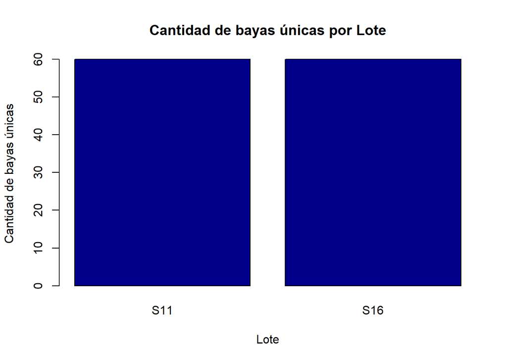

- El análisis revela que cada lote contiene una cantidad consistente de bayas únicas.
- Se observa que cada lote tiene 60 bayas únicas.

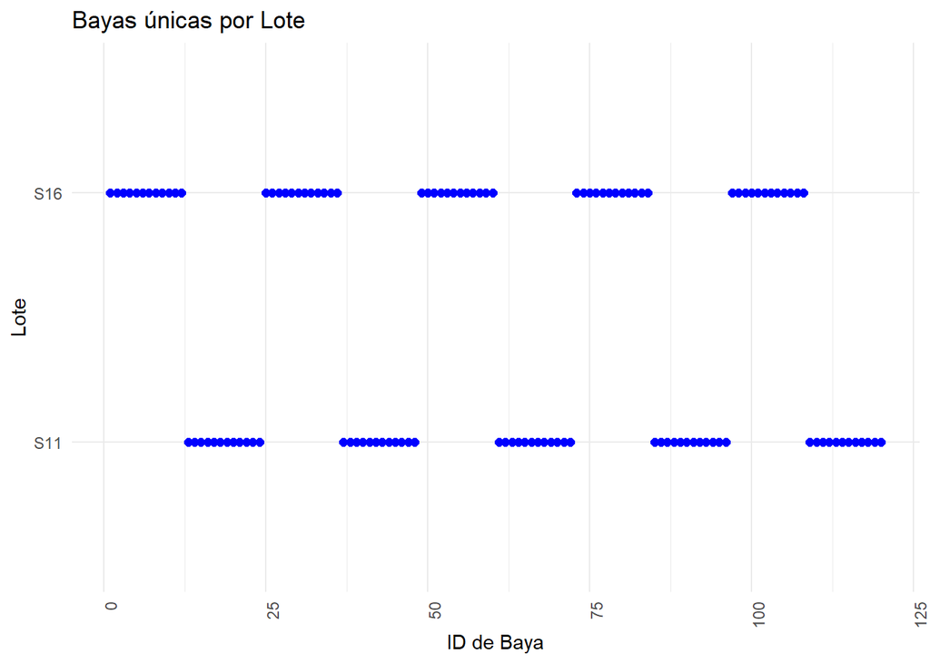

- El gráfico confirma que no hay duplicidad en los identificadores de las bayas dentro de los lotes. C
- Cada baya tiene una única asignación a un lote específico.
- La ausencia de duplicidad indica que el sistema de marcación de bayas es consistente y no presenta errores de asignación.
- La disposición de las bayas por lote muestra un patrón estructurado, sugiere que existe un enfoque sistemático en la recolección y asignación de las bayas a los lotes.

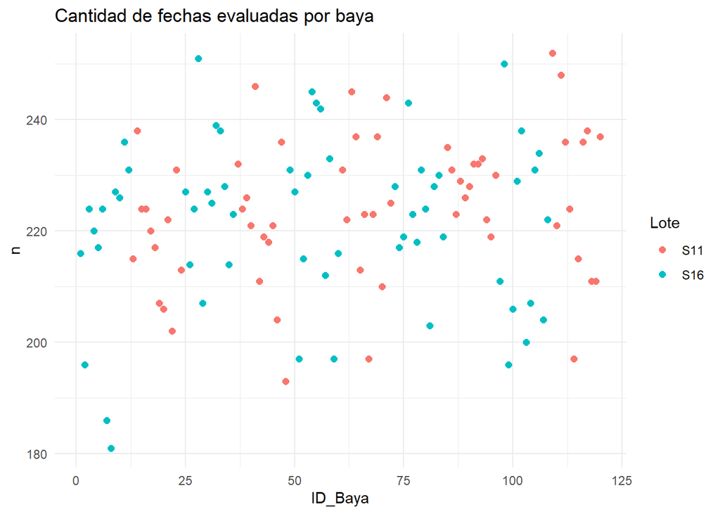

- El gráfico muestra que la cantidad de fechas evaluadas por baya no es uniforme entre las bayas y los lotes.
- Hay bayas con una cantidad significativamente menor de fechas evaluadas, especialmente notorio en la parte inferior del gráfico.
- La variabilidad en la cantidad de fechas evaluadas puede indicar diferencias en la duración de la observación o problemas en el proceso de recolección de datos.
- Esto puede sugerir la posibilidad de **mortandad de bayas o una evaluación incompleta para algunas bayas**.

### Análisis de la variable “ID_Baya”

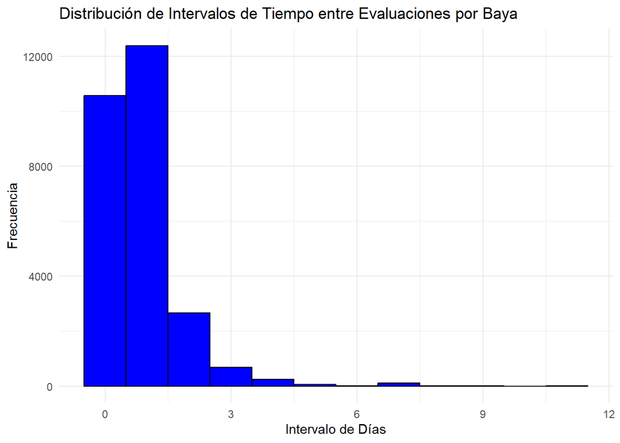

- El histograma indica la variabilidad en los intervalos entre evaluaciones. La presencia de intervalos largos, como de 6 a 12 días, sugiere que en algunos casos las evaluaciones no son tan frecuentes.
- Invito al lector a identificar si ciertos ID_Baya tienen intervalos de tiempo inusualmente largos y verificar si hay patrones específicos asociados con sus casos.

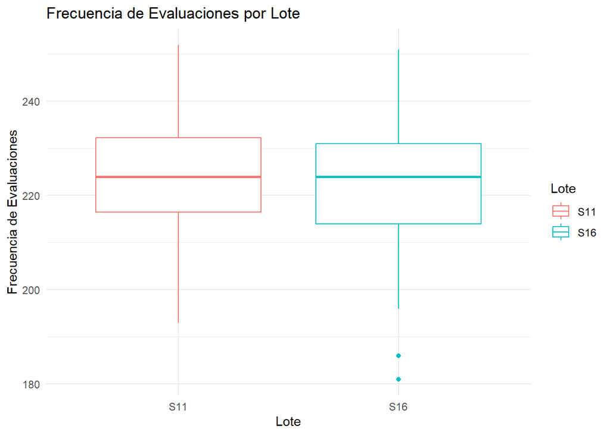

- El gráfico de caja muestra la variabilidad en la frecuencia de evaluaciones por lote. La presencia de un máximo alrededor de 250 evaluaciones por lote sugiere que, en general, las evaluaciones pueden estar agrupadas en ciertos períodos o lotes específicos.
- **Tener en cuenta que es una inferencia respecto la data entregada**

### Analisis adicional

Para continuar con el analisis de Mes de Marcación, Estadio, las pruebas estadisticas y el modelado tenemos que realizar un cambio en la data ya que el objetivo es hallar la cantidad de dias que transcurren desde flor cerrada hasa azul, a continuacion vemos como queda estructurada la data que es la misma pero dandole un cambio que permita los analisis posteriores.

```
## # A tibble: 5 × 6
##   ID_Baya Lote  Mes_Marcacion Estadio        Condicion  Dias
##     <dbl> <fct> <fct>         <fct>              <dbl> <dbl>
## 1       1 S16   Setiembre     Flor Cerrada           1    10
## 2       1 S16   Setiembre     Flor Abierta           1     4
## 3       1 S16   Setiembre     Cuajo                  1    12
## 4       1 S16   Setiembre     Verde Temprano         1    13
## 5       1 S16   Setiembre     Verde Medio            1    13
```

### Proporcion de Maduración o Viabilidad

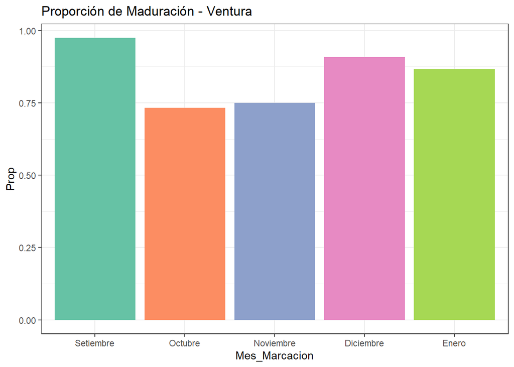

- Se observa que en los meses de octubre y noviembre se presenta una viabilidad baja de tan solo el 75%. Esto sugiere que las condiciones durante estos meses pueden no ser ideales para la maduración de las bayas.
- Algo adicional y a tener en cuenta es que la viabilidad de las bayas tiene muy escasas probabilidades de ser el 100%. Este hecho puede estar relacionado con factores extras.

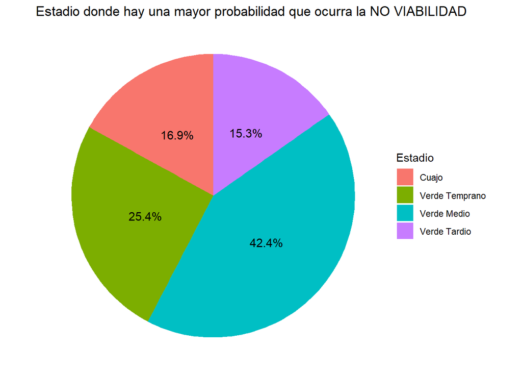

- Observamos que segùn la data analizada la mayor mortandad se da cuando la baya esta en el estadio Verde Medio con un 42% y el estadio donde menos se registran datos con esta caracteristica es en Verde Tardio con un 15%.
- Se observa que el 15% en Verde Tardío podría necesitar un análisis más detallado, ya que podría estar relacionado con condiciones climáticas que podrían hacer que las bayas pasen directamente de Verde Tardío a Azul, clasificándose erróneamente como no viables.

### Mes de Marcacion y Estadio

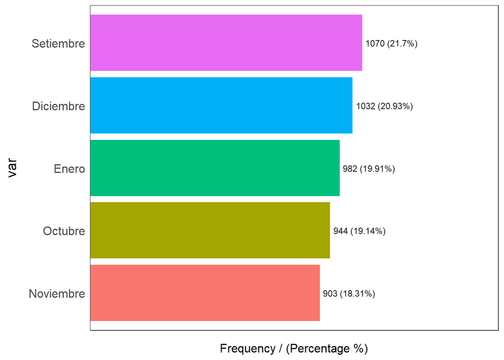

```
##         var frequency percentage cumulative_perc
## 1 Setiembre      1070      21.70           21.70
## 2 Diciembre      1032      20.93           42.63
## 3     Enero       982      19.91           62.54
## 4   Octubre       944      19.14           81.68
## 5 Noviembre       903      18.31          100.00
```

- Observamos que tenenemos 5 meses de marcacion las cuales van desde setiembre hasta el mes de marcacion de enero.
- Se observa que las bayas que se marcaron en setiembre son las mas evaluadas con el 21% y que las bayas marcadas en el mes de noviembre se evaluaron menos con un 18% de veces.
- La variabilidad en la cantidad de datos para cada mes sugiere que el análisis del estadio debe considerar esta distribución, ya que los meses con más datos pueden influir desproporcionadamente en los resultados.

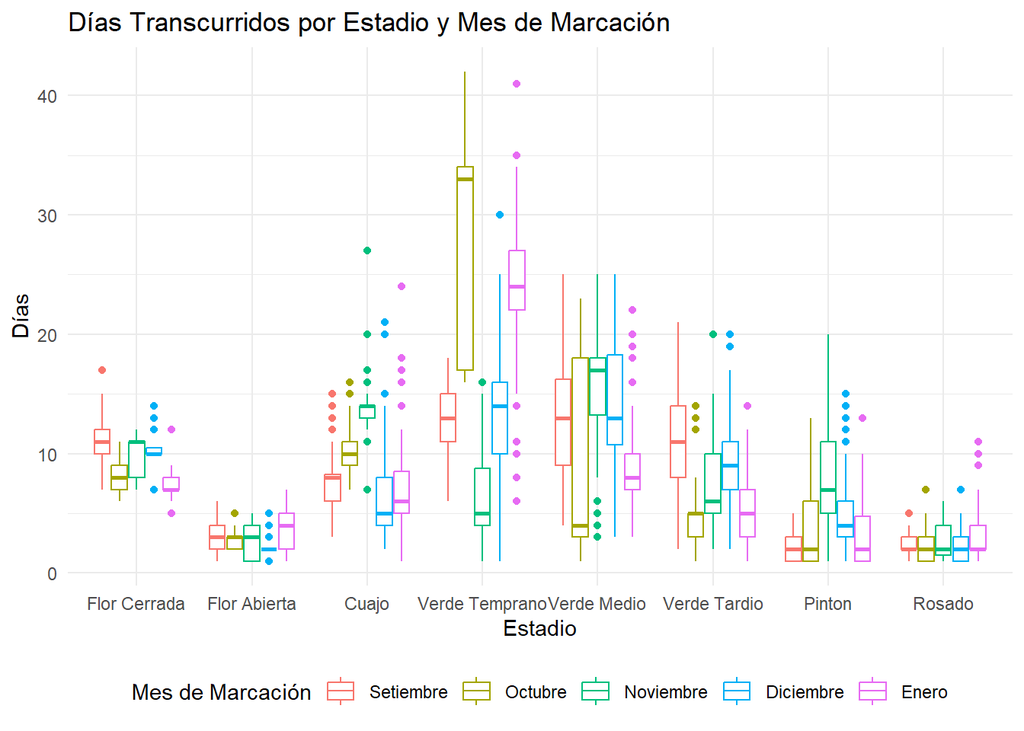

Se puede observar que los dias transcurridos para alcanzar diferentes estadios de maduracion muestra variaciones significativas.

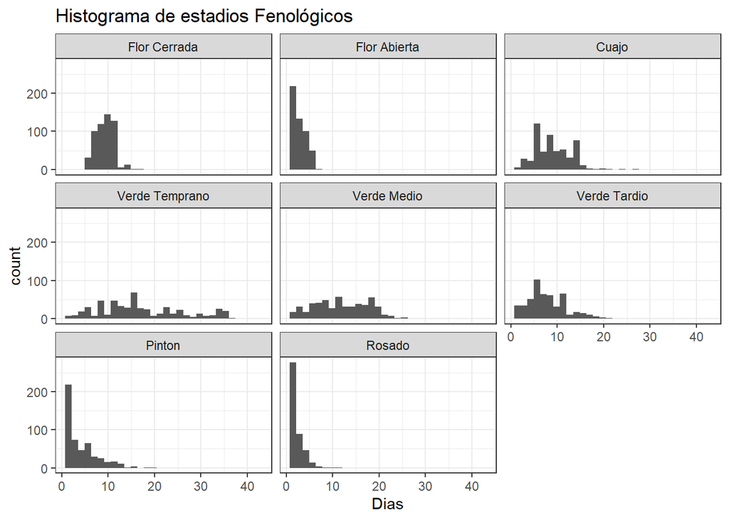

## Investigacion Final días de estadio Flor Cerrada a estadio Azul

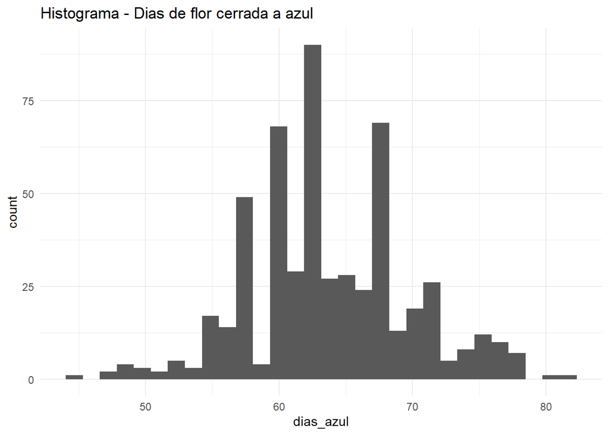

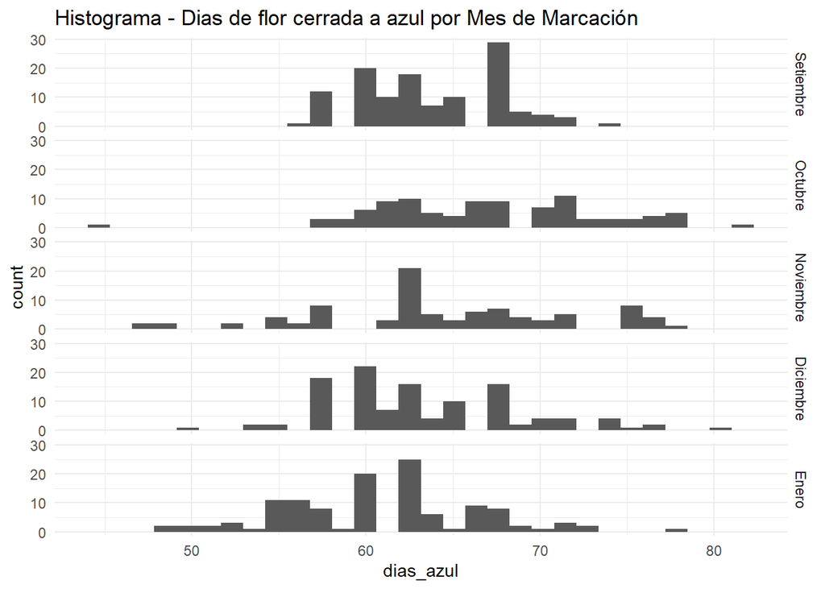

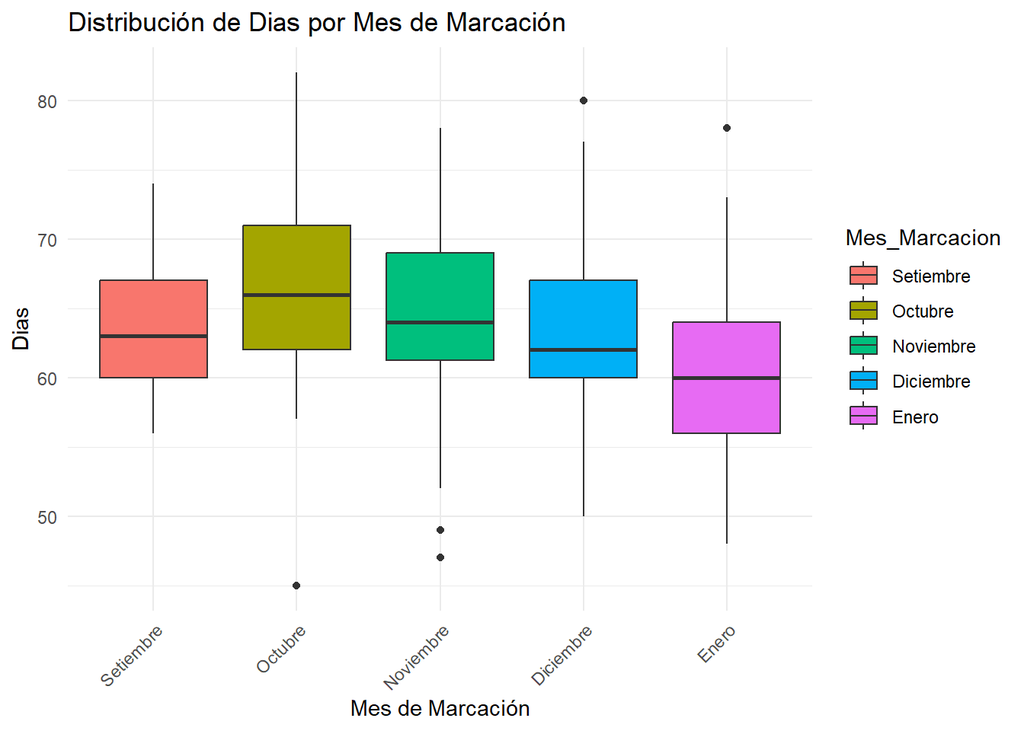

- Los tiempos de transición desde “Flor Cerrada” a “Azul” varían entre los meses. Octubre muestra la mayor media y desviación estándar, indicando mayor variabilidad en comparación con otros meses.
- Los tiempos de transición tienden a ser más largos en Octubre y más cortos en Enero. Esta variabilidad podría estar relacionada con las condiciones climáticas estacionales que afectan el desarrollo de las bayas.
- Aunque la media es bastante consistente entre la mayoría de los meses, las diferencias en la desviación estándar sugieren que algunos meses tienen una mayor variabilidad en los tiempos de transición.

## Prueba de Normalidad

Dado que se está analizando el tiempo desde “Flor Cerrada” a estadio “Azul” y este contiene una carateristica que es “Mes de Marcación, **no se puede o debe hacer algun modelado o inferir cosas sin antes haber realizado las pruebas de normalidad**, a continuación realizamos la prueba de”Shapiro-Wilk Test”

```
## # A tibble: 5 × 4
##   Mes_Marcacion     n all_identical p_value
##   <fct>         <int> <lgl>           <dbl>
## 1 Setiembre       120 FALSE         0.00368
## 2 Octubre          96 FALSE         0.0240
## 3 Noviembre        90 FALSE         0.0403
## 4 Diciembre       116 FALSE         0.00313
## 5 Enero           119 FALSE         0.124
```

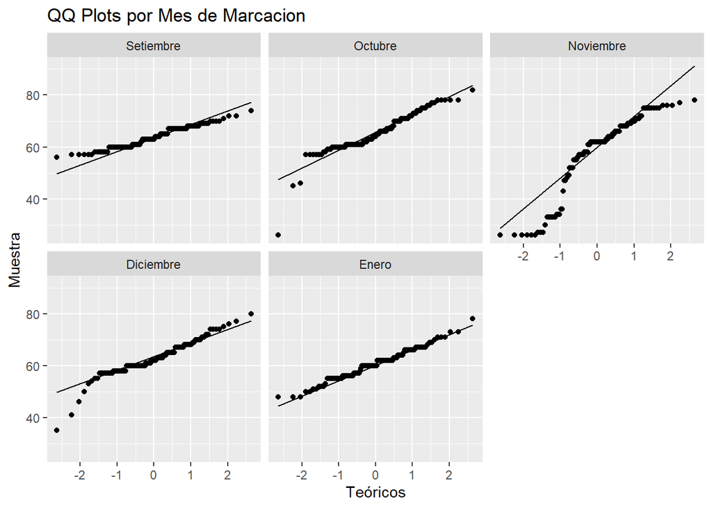

- Setiembre, Octubre, Noviembre y Diciembre: Los p_value son menores que 0.05, lo que indica que podemos rechazar la hipótesis nula de normalidad para estos meses. Esto sugiere que los datos de estos meses no siguen una distribución normal.
- Para el mes de Enero el p-p_value es mayor que 0.05, lo que significa que no podemos rechazar la hipótesis nula de normalidad para este mes. Esto sugiere que los datos de este mes podrían seguir una distribución normal.
- En el gràfico de QQ- Plot efectivamente corroboramos ello, visualizando en los extremos puntos muy bajo o puntos muy altos salvo el mes de Enero, donde la linea recta diagonal pasa casi en todos los puntos.

```
## # A tibble: 5 × 2
##   Mes_Marcacion p_value_log
##   <fct>               <dbl>
## 1 Setiembre        4.10e- 3
## 2 Octubre          4.17e-12
## 3 Noviembre        1.48e-11
## 4 Diciembre        3.38e- 8
## 5 Enero            9.44e- 2
```

- A pesar de realizar una tranformación logaritmica se sigue rechazando la normalidad de los datos.
- Los datos de enero podrían seguir una distribución normal tras la transformación logarítmica.

**Prueba de Kruskal**

Es una prueba no paramétrica al demostrar que los datos no siguen una normalidad.

En este caso busco ver si existen diferencias significativas entre los días de cada mes de marcación.

```
##
##  Kruskal-Wallis rank sum test
##
## data:  dias_azul by Mes_Marcacion
## Kruskal-Wallis chi-squared = 57.345, df = 4, p-value = 0.00000000001047
```

Hipótesis:

- Hipótesis nula (H0): Las distribuciones de días transcurridos son iguales para todos los meses de marcación.
- Hipótesis alternativa(H1): Al menos una de las distribuciones de días transcurridos es diferente para los meses de marcación.

Dado que el valor de p es extremadamente bajo (cercano a 0), rechazamos la hipótesis nula. Esto indica que existen diferencias significativas entre la distribución de días transcurridos entre al menos algunos de los meses de marcación.

**Pruebas Post-Hoc**

Si una comparación muestra un p-valor ajustado (p-adj) menor que 0.05, significa que existe una diferencia estadísticamente significativa entre los dos grupos comparados. Esto nos dice que las distribuciones de los días transcurridos entre los meses específicos son diferentes.

```
##               Comparison          Z               P.unadj                P.adj
## 1      Diciembre - Enero  3.0758833 0.0020987998102620555 0.020987998102620555
## 2  Diciembre - Noviembre -1.6537137 0.0981856915236892364 0.981856915236892336
## 3      Enero - Noviembre -4.5358126 0.0000057382123193457 0.000057382123193457
## 4    Diciembre - Octubre -4.3829606 0.0000117077292428760 0.000117077292428760
## 5        Enero - Octubre -7.3336344 0.0000000000002239936 0.000000000002239936
## 6    Noviembre - Octubre -2.5384214 0.0111353823501724718 0.111353823501724722
## 7  Diciembre - Setiembre -1.1456326 0.2519471957359660785 1.000000000000000000
## 8      Enero - Setiembre -4.2552229 0.0000208840836068410 0.000208840836068410
## 9  Noviembre - Setiembre  0.5961343 0.5510855018526767957 1.000000000000000000
## 10   Octubre - Setiembre  3.3270345 0.0008777550946804788 0.008777550946804788
```

Podemos observar que :

- Diciembre - Noviembre: No hay evidencia significativa de diferencia.
- Diciembre - Setiembre: No hay evidencia significativa de diferencia.
- Noviembre - Octubre: No hay evidencia significativa de diferencia.
- Noviembre - Setiembre: No hay evidencia significativa de diferencia.
- La falta de diferencias significativas indica que no hay cambios sustanciales en los días transcurridos entre ciertos meses. Esto sugiere que el tiempo de maduración es consistente entre esos meses.
- Cuando esto ocurre, no se requiere un cambio inmediato en las prácticas agrícolas para los meses que no muestran diferencias significanivas

## Modelado Estadístico

- Dado que las pruebas de normalidad (como la prueba de Shapiro-Wilk y los QQ plots) han indicado que los datos no siguen una distribución normal, es apropiado considerar técnicas estadísticas que no asumen normalidad. El análisis de supervivencia es una buena opción en este caso, especialmente en el tiempo hasta que ocurre un evento (en este caso, el tiempo desde “Flor Cerrada” hasta “Azul”).

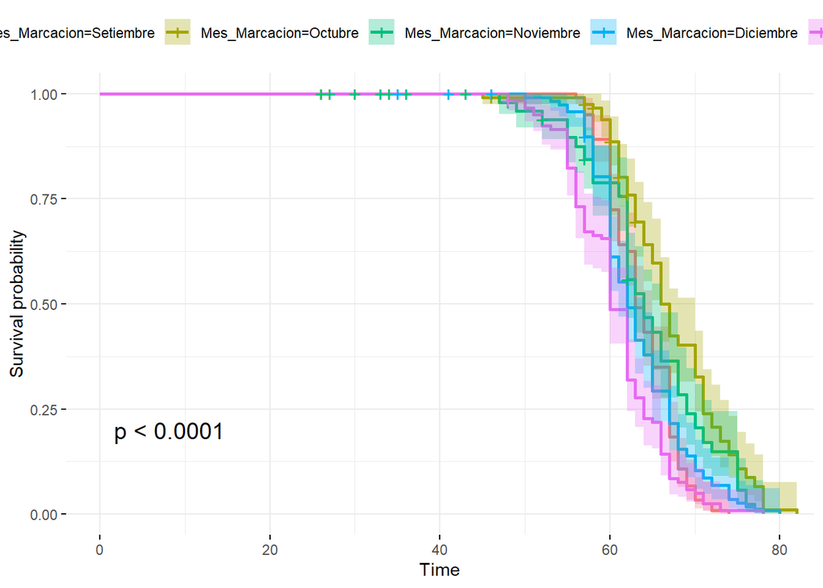

- Setiembre: El tiempo mediano hasta que el estadio llega a azul es de 63 días, con un intervalo de confianza del 95% que va de 63 a 65 días.
- Octubre: La mediana es de 67 días, con un intervalo de confianza del 95% de 66 a 70 días.
- Noviembre: La mediana es de 64 días, con un intervalo de confianza de 62 a 66 días.
- Diciembre: La mediana es de 62 días, con un intervalo de confianza de 61 a 64 días.
- Enero: La mediana es de 60 días, con un intervalo de confianza de 60 a 62 días.

**Modelo de Cox**

Ese modelo es útil para:

- Evaluar el impacto de covariables (como el mes de marcación) en el tiempo hasta el evento.
- Determinar si hay diferencias significativas en los tiempos de supervivencia entre los diferentes niveles de la covariable.
- Aqui solo mostrare con respecto a la variable mes de marcación

```
## Call:
## coxph(formula = Surv(dias_azul, Condicion) ~ Mes_Marcacion, data = dias_azul)
##
##   n= 600, number of events= 541
##
##                            coef exp(coef) se(coef)      z    Pr(>|z|)
## Mes_MarcacionOctubre   -0.71423   0.48957  0.14185 -5.035 0.000000478 ***
## Mes_MarcacionNoviembre -0.37880   0.68468  0.14273 -2.654     0.00796 **
## Mes_MarcacionDiciembre -0.06984   0.93255  0.13162 -0.531     0.59571
## Mes_MarcacionEnero      0.37847   1.46005  0.12997  2.912     0.00359 **
## ---
## Signif. codes:  0 '***' 0.001 '**' 0.01 '*' 0.05 '.' 0.1 ' ' 1
##
##                        exp(coef) exp(-coef) lower .95 upper .95
## Mes_MarcacionOctubre      0.4896     2.0426    0.3707    0.6465
## Mes_MarcacionNoviembre    0.6847     1.4605    0.5176    0.9057
## Mes_MarcacionDiciembre    0.9325     1.0723    0.7205    1.2070
## Mes_MarcacionEnero        1.4600     0.6849    1.1317    1.8836
##
## Concordance= 0.613  (se = 0.015 )
## Likelihood ratio test= 67.94  on 4 df,   p=0.00000000000006
## Wald test            = 66.69  on 4 df,   p=0.0000000000001
## Score (logrank) test = 69.94  on 4 df,   p=0.00000000000002
```

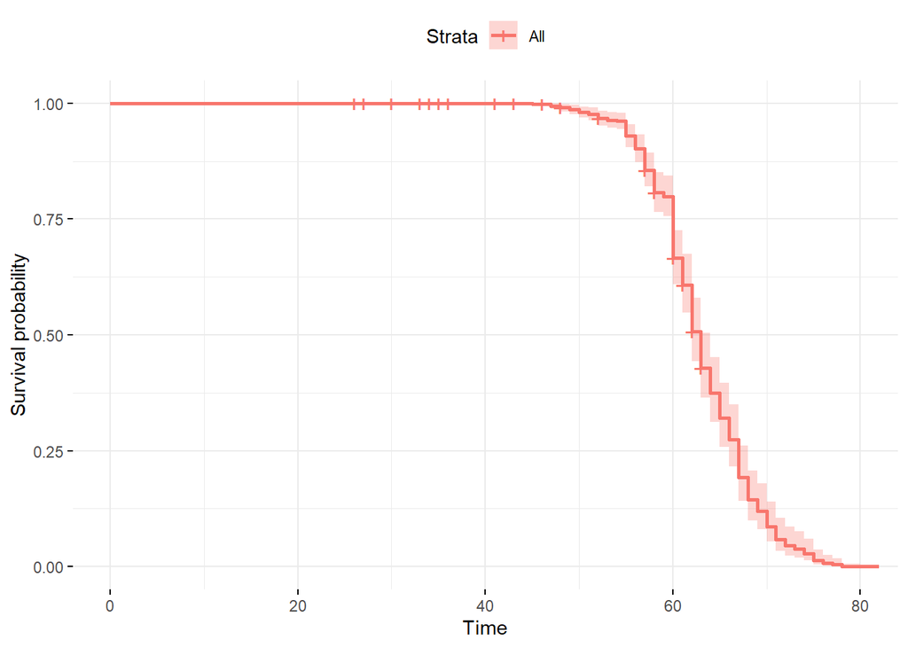